# Variable selection

# The data

## ecoregions

- Columns relative to the ecoregion identification, named `ecoregion_x` describing the name, biome, realm, continent and area of the ecoregion in squared kilometers.
- Columns with proxies of bias in the species data of the ecoregions, named `bias_x`, with the number of records, records per area unit, number of species per record, and number of species per record per squared kilometre.
- Columns relative to plant species richness, named `richness_x`, with richness values for diferent taxonomic levels (from species to family) for different groups of plants (all plants, vascular plants, trees, and grasses).
- Columns named `rarity_x`` with *rarity-weighted richness* values (sum of 1 divided by the number of presences of each species present in the ecoregion, and sum of 1 divided by the number of ecoregions in which each species can be found) for different taxonomic groups (all plants, vascular plants, trees, and grasses) and different taxonomic levels (species and genus).
- Columns named `exclusive_x` with the number and percentage of exclusive taxa of the given ecoregion for different plant groups and taxonomic levels.
- Features of the ecoregion’s neighbors (either direct neighbors, or other ecoregions within 100km when the ecoregion is isolated by the ocean), with columns named `neighbors_x`, containing values such as the number of neighbors, the sum of the neighbor’s area, the total percentage of shared edge with those neighbors, their average aridity, and their number of species, genera, classes, and vamilies.
- Columns describing the impact of human activity in the ecoregion, named `human_x`, including the conservation assessment by Dinerstein et al. (2017), the human footpring (Sanders citation), and the human population (SIEDAC citation).
- Columns named `climate_x` describing the average climatic conditions within a given ecoregion.
- Columns named `landcover_x` representing cover percentage of bare soil, herbs and trees (citation modis continuous fields) and NDVI (citation of modis product).
- Geography columns named `geo_x` with the range and average of the latitude and longitude of each ecoregion.
- Columns representing elevation stats, named `topography_elevation_x`.
- A complete set of columns named `fragmentation_x` describing the fragmentation of each ecoregion computed at 5km resolution with the package `landscapemetrics` (citation).
- Betadiversity measures (columns are named `betadiversity_x`) between each given ecoregion and its neighbors for different taxonomic levels and plant groups.

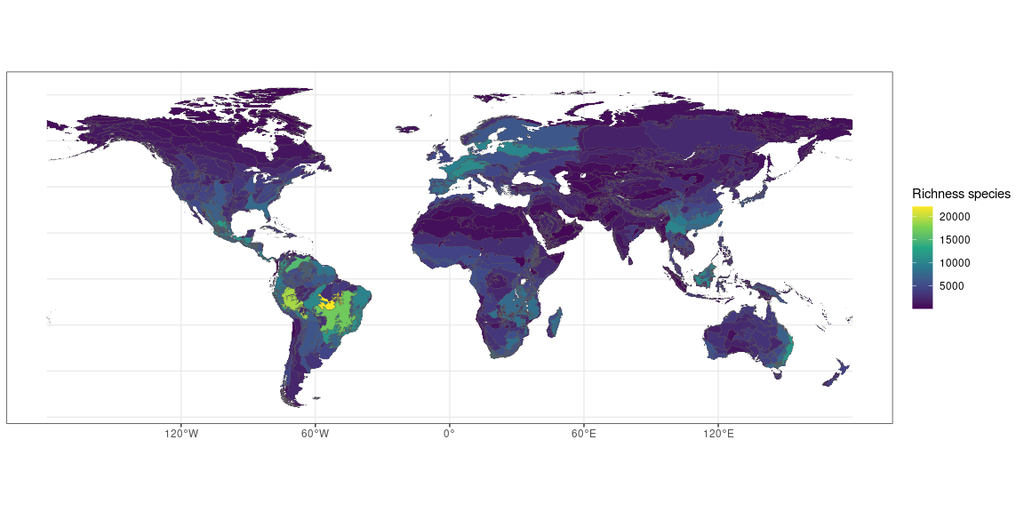

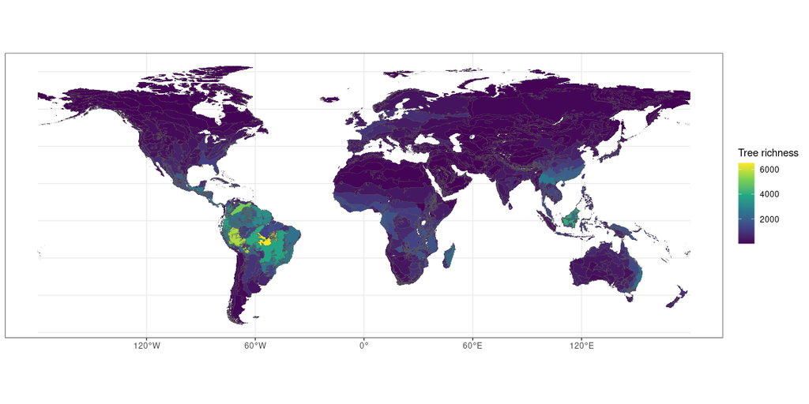

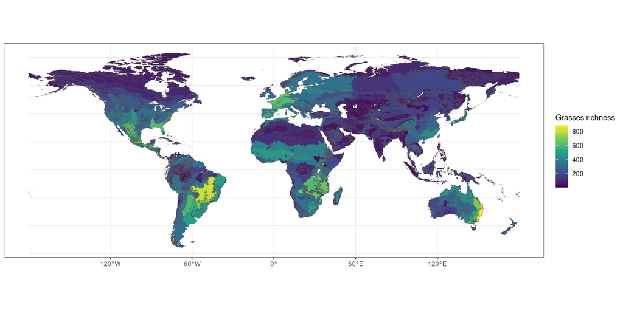

## ecoregions_pairs

- `ecoregion_name` and `neighbor_name`: names of the pair.
- `ecoregion_area` and `neighbor_area`: area in squared kilometres of each ecoregion in the pair.
- `ecoregion_climate_aridity_index_average` and `neighbor_climate_aridity_index_average`: the average aridity index of each ecoregion in the pair.
- The `x_geo_x` columns contain the average latitude and longitude of each ecoregion pair, so basically these are the ecoregion centroids.
- The columns `x_toporgraphy_elevation_average` contain the average elevation values of each ecoregion.
- The columns `connection_x` are data on the connectivity between both ecoregions in the pair. Questions such as “is the pair of ecoregions in the same biome/continent?”, or “are they direct neighbors?”, and the length of the shared edge when they are neighbors are answered by the data in these columns.
- The columns `richness_x_diff` have the differences in richness for each pair of ecoregions.
- The columns `climate_x_diff`, `human_x_diff`, `landcover_x_diff`, and `topography_elevation_diff` represent differences in mean climatic, human activity, landcover, and elevation values between ecoregions pairs.
- The columns `betadiversity_x` represent betadiversity values between each ecoregion pair for different taxonomic levels.
- The overlap in the environmental space, or lack thereof, for each pair of ecoregions is stored in the columns `environmental_overlap_x`.

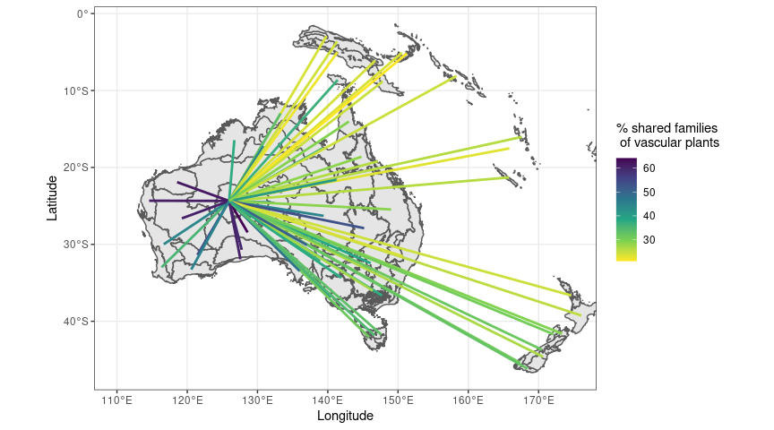

# Assessing bias

- `bias_area_km2`: area of the ecoregion in squared kilometers.
- `bias_records`: Number of spatial records available for any species in the GBIF *Plantae* dataset for the given ecoregion.
- `bias_records_per_km2`: Number of GBIF records per squared kilometer. Gives an idea of the density of the spatial sampling of the ecoregion. A low number indicates that the ecoregion has not been sample thoroughly, or that the data available in GBIF Plantae might be missing data from such ecoregion.
- `bias_species_per_record`: Represents the number of species discovered per presence record available. A high number indicates that the ecoregion is likely poorly sampled. However, it also indicates that the sampling is diverse, that is, it is not focused in a particular group of species, which at the end might lead to a representative species pool in some cases.
- `bias_species_per_record_per_km2`: Computed as `bias_species_per_record / bias_records_per_km2`, it represents the most complete bias measure available for the `ecoregions` dataset.

```r
temp.df <- dplyr::select(
  ecoregions,
  ecoregion_name,
  richness_species_vascular,
  ecoregion_area_km2,
  bias_records,
  bias_records_per_km2,
  bias_species_per_record,
  bias_species_per_record_per_km2
) %>%
  dplyr::mutate(
   ecoregion_area_km2 = round(ecoregion_area_km2, 0),
   bias_records_per_km2 = round(bias_records_per_km2, 4),
   bias_species_per_record = round(bias_species_per_record, 4),
   bias_species_per_record_per_km2 = round(bias_species_per_record_per_km2, 4)
  ) %>%
 dplyr::arrange(desc(bias_species_per_record_per_km2))

kableExtra::kable(temp.df[1:10, ], caption = "The 10 ecoregions with a higher potential bias.") %>% kableExtra::kable_styling()
```

The 10 ecoregions with a higher potential bias.

| ecoregion_name | richness_species_vascular | ecoregion_area_km2 | bias_records | bias_records_per_km2 | bias_species_per_record | bias_species_per_record_per_km2 |
| --- | --- | --- | --- | --- | --- | --- |
| Tarim Basin deciduous forests and steppe | 15 | 54533 | 17 | 0.0003 | 1.0000 | 3207.8262 |
| Qilian Mountains subalpine meadows | 26 | 73284 | 26 | 0.0004 | 1.0000 | 2818.6201 |
| Sumatran peat swamp forests | 39 | 87120 | 49 | 0.0006 | 0.8163 | 1451.4033 |
| West Sahara desert | 487 | 743609 | 660 | 0.0009 | 0.7924 | 892.8093 |
| Eastern Gobi desert steppe | 150 | 282369 | 253 | 0.0009 | 0.7036 | 785.2292 |
| Bohai Sea saline meadow | 18 | 11565 | 18 | 0.0016 | 1.0000 | 642.5025 |
| Rann of Kutch seasonal salt marsh | 45 | 27839 | 45 | 0.0016 | 1.0000 | 618.6385 |
| Arabian sand desert | 308 | 713576 | 609 | 0.0009 | 0.5123 | 600.2891 |
| Sudd flooded grasslands | 208 | 188113 | 262 | 0.0014 | 0.7939 | 570.0060 |
| Central Asian southern desert | 439 | 567375 | 693 | 0.0012 | 0.6364 | 521.0058 |

```r
rm(temp.df)
```

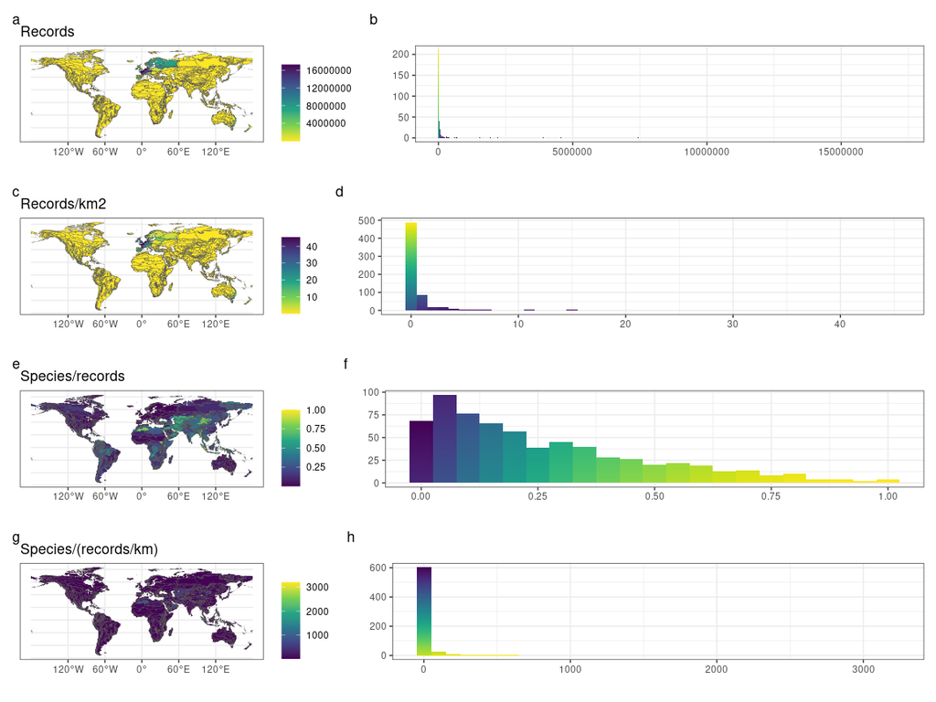

Considering how skewed most bias measures are, I believe that `bias_species_per_record` is the most informative variable regarding the potential incompleteness of species list for understampled ecoregions. As such, the bias variables selected are `bias_area_km2`, since area is an important covariate with the species richness of any region, and `bias_species_per_record`.

```r
bias.variables <- c(
  "bias_area_km2",
  "bias_species_per_record"
)
```

## Organizing the data in lists

To avoid cluttering the R environment with objects, here I organize the datasets `ecoregions` and `ecoregions_pairs` in two lists with their respective names, that also store information about the names of the response variables and predictors of each conceptual group.

```r
#organizing the ecoregions_pairs data
ecoregions_pairs.data <- ecoregions_pairs

#creating list
ecoregions_pairs <- list()

#adding the data
ecoregions_pairs$data <- ecoregions_pairs.data

#column names
ecoregions_pairs$names <- colnames(ecoregions_pairs$data)

#names of response variables
ecoregions_pairs$response.variables$richness <- ecoregions_pairs$names[grepl("^richness", ecoregions_pairs$names)]
ecoregions_pairs$response.variables$betadiversity <- unique(c(
  ecoregions$names[grepl("^betadiversity_a", ecoregions$names)],
  ecoregions$names[grepl("^betadiversity_a_percent", ecoregions$names)],
  ecoregions_pairs$names[grepl("^betadiversity_Bsor", ecoregions_pairs$names)],
  ecoregions_pairs$names[grepl("^betadiversity_Bsim", ecoregions_pairs$names)],
  ecoregions_pairs$names[grepl("^betadiversity_R", ecoregions_pairs$names)],
  ecoregions_pairs$names[grepl("^betadiversity_R_percent", ecoregions_pairs$names)]
  ))
ecoregions_pairs$response.variables$all <- c(
  ecoregions_pairs$response.variables$richness,
  ecoregions_pairs$response.variables$betadiversity
)

#selecting predictors
ecoregions_pairs$predictive.variables$connection <- ecoregions_pairs$names[grepl("^connection", ecoregions_pairs$names)]
ecoregions_pairs$predictive.variables$human <- ecoregions_pairs$names[grepl("^diff_human", ecoregions_pairs$names)]
ecoregions_pairs$predictive.variables$climate <- ecoregions_pairs$names[grepl("^diff_climate", ecoregions_pairs$names)]
ecoregions_pairs$predictive.variables$landcover <- ecoregions_pairs$names[grepl("^diff_landcover", ecoregions_pairs$names)]
ecoregions_pairs$predictive.variables$topography <- ecoregions_pairs$names[grepl("^diff_topography", ecoregions_pairs$names)]
ecoregions_pairs$predictive.variables$overlap <- ecoregions_pairs$names[grepl("^environmental", ecoregions_pairs$names)]
ecoregions_pairs$predictive.variables$autocorrelation <- NA
ecoregions_pairs$predictive.variables$all <- c(
  ecoregions_pairs$predictive.variables$connection,
  ecoregions_pairs$predictive.variables$human,
  ecoregions_pairs$predictive.variables$climate,
  ecoregions_pairs$predictive.variables$landcover,
  ecoregions_pairs$predictive.variables$topography,
  ecoregions_pairs$predictive.variables$overlap
)

rm(ecoregions_pairs.data)
```

# Understanding the relationship between response variables

## `ecoregions` dataset

In the `ecoregions` dataset there are several groups of response variables computed for different taxonomic levels, and relationships among these variables are to be expected. Understanding these relationships will help downstream in understanding why models for different response variables show similar structures.

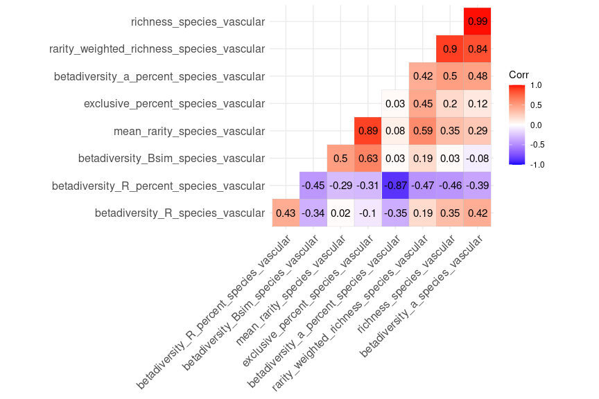

```r
temp.df <- ecoregions$data[, c(
  "richness_species_vascular",
  "rarity_weighted_richness_species_vascular",
  "mean_rarity_species_vascular",
  "exclusive_percent_species_vascular",
  "betadiversity_a_species_vascular",
  "betadiversity_a_percent_species_vascular",
  "betadiversity_Bsim_species_vascular",
  "betadiversity_R_species_vascular",
  "betadiversity_R_percent_species_vascular"
)] %>%
  scale() %>%
  as.data.frame()

ggcorrplot(
  cor(temp.df),
  hc.order = TRUE,
  type = "lower",
   lab = TRUE
  )
```

- `mean_rarity_species_vascular` and `exclusive_percent_species_vascular`.
- `rarity_weighted_richness_species_vascular` and `betadiversity_a_species_vascular`.
- `richness_species_vascular` and `rarity_weighted_richness_species_vascular`
- `richness_species_vascular` and `betadiversity_a_species_vascular`.

One pair is highly negatively correlated:

- `betadiversity_R_percent_species_vascular` and `betadiversity_a_percent_species_vascular`

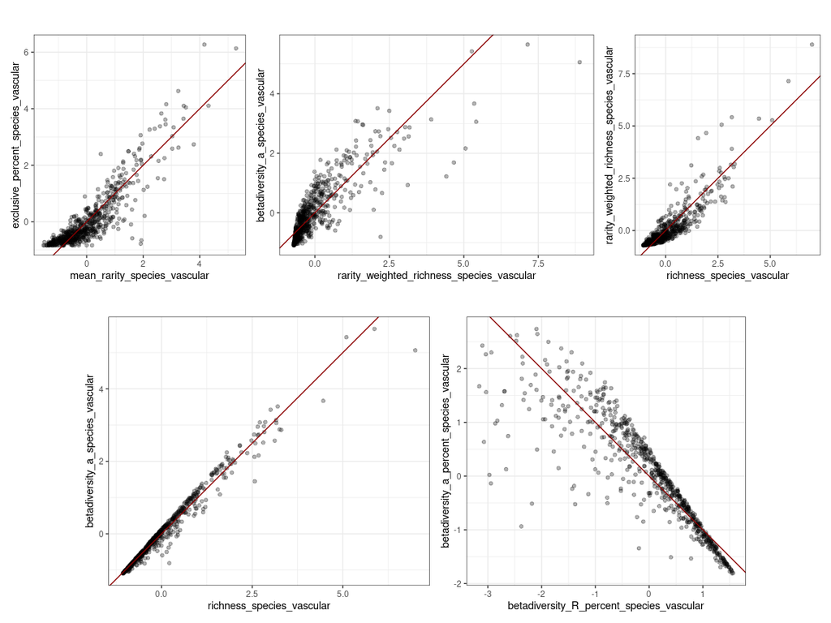

```r
p1 <- ggplot2::ggplot(data = temp.df) +
  ggplot2::aes(
    x = mean_rarity_species_vascular,
    y = exclusive_percent_species_vascular
    ) +
  ggplot2::geom_point(alpha = 0.3) +
  ggplot2::coord_fixed(ratio = 1) +
  ggplot2::geom_abline(intercept = 0, slope = 1, col = "red4")

p2 <- ggplot2::ggplot(data = temp.df) +
  ggplot2::aes(
    x = rarity_weighted_richness_species_vascular,
    y = betadiversity_a_species_vascular
    ) +
  ggplot2::geom_point(alpha = 0.3) +
  ggplot2::coord_fixed(ratio = 1) +
  ggplot2::geom_abline(intercept = 0, slope = 1, col = "red4")

p3 <- ggplot2::ggplot(data = temp.df) +
  ggplot2::aes(
    x = richness_species_vascular,
    y = rarity_weighted_richness_species_vascular
    ) +
  ggplot2::geom_point(alpha = 0.3) +
  ggplot2::coord_fixed(ratio = 1) +
  ggplot2::geom_abline(intercept = 0, slope = 1, col = "red4")

p4 <- ggplot2::ggplot(data = temp.df) +
  ggplot2::aes(
    x = richness_species_vascular,
    y = betadiversity_a_species_vascular
    ) +
  ggplot2::geom_point(alpha = 0.3) +
  ggplot2::coord_fixed(ratio = 1) +
  ggplot2::geom_abline(intercept = 0, slope = 1, col = "red4")

p5 <- ggplot2::ggplot(data = temp.df) +
  ggplot2::aes(
    x = betadiversity_R_percent_species_vascular,
    y = betadiversity_a_percent_species_vascular
    ) +
  ggplot2::geom_point(alpha = 0.3) +
  ggplot2::coord_fixed(ratio = 1) +
  ggplot2::geom_abline(intercept = 0, slope = -1, col = "red4")

(p1 | p2 | p3) / (p4 | p5)
```

```r
rm(p1, p2, p3, p4, p5, temp.df)
```

Considering these correlations, only `betadiversity_a_x` and `betadiversity_R_percent` seem to perfectly mirror other variables, and therefore I remove them from the pool of response variables.

```r
#re-doing the betadiversity response variables
ecoregions$response.variables$betadiversity <- unique(c(
  ecoregions$names[grepl("^betadiversity_a_percent", ecoregions$names)],
  ecoregions$names[grepl("^betadiversity_Bsor", ecoregions$names)],
  ecoregions$names[grepl("^betadiversity_Bsim", ecoregions$names)],
  ecoregions$names[grepl("^betadiversity_R", ecoregions$names)][!(ecoregions$names[grepl("^betadiversity_R", ecoregions$names)] %in% ecoregions$names[grepl("^betadiversity_R_percent", ecoregions$names)])]
  ))
ecoregions$response.variables$all <- c(
  ecoregions$response.variables$richness,
  ecoregions$response.variables$rarity.weighted.richness,
  ecoregions$response.variables$exclusive,
  ecoregions$response.variables$mean.rarity,
  ecoregions$response.variables$betadiversity
)
```

## ecoregions_pairs

Here I repeat the operation for the table `ecoregions_pairs`.

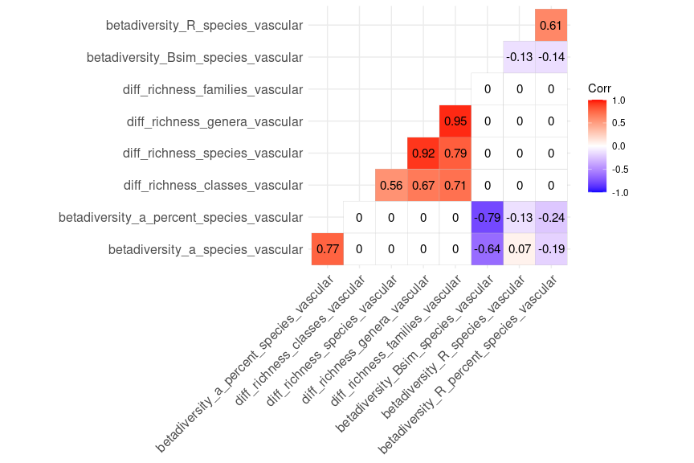

```r
temp.df <- ecoregions_pairs$data[, c(
  "diff_richness_species_vascular",
  "diff_richness_genera_vascular",
  "diff_richness_families_vascular",
  "diff_richness_classes_vascular",
  "betadiversity_a_species_vascular",
  "betadiversity_a_percent_species_vascular",
  "betadiversity_Bsim_species_vascular",
  "betadiversity_R_species_vascular",
  "betadiversity_R_percent_species_vascular"
)] %>%
  scale() %>%
  as.data.frame()

ggcorrplot(
  cor(temp.df),
  hc.order = TRUE,
  type = "lower",
   lab = TRUE
  )
```

```r
rm(temp.df)
```

The correlogram shows that only close taxonomic are highly correlated. No variables are removed at this stage.

# Reducing the multicollinearity of the predictors

The predictors in `ecoregions` and `ecoregions_pairs` are separated in several groups. Here I apply a within-group variance inflation analysis first, to reduce the number of predictors on each group, to later apply the same analysis to all the remaining predictors.

## ecoregions

### neighbors variables

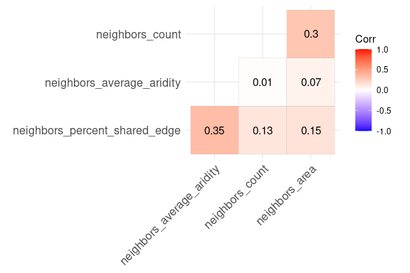

```r
ggcorrplot(
  cor( ecoregions$data[, ecoregions$predictive.variables$neighbors]),
  hc.order = TRUE,
  type = "lower",
   lab = TRUE
  )
```

### human variables

The variable `human_conservation_assessment` is categorical, and removed right away

```r
ecoregions$predictive.variables$human <- ecoregions$predictive.variables$human[ecoregions$predictive.variables$human != "human_conservation_assessment"]

ecoregions$predictive.variables$all <- ecoregions$predictive.variables$all[ecoregions$predictive.variables$all != "human_conservation_assessment"]
```

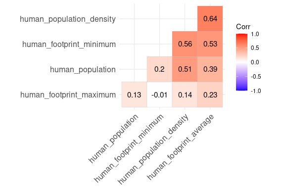

```r
ggcorrplot(
  cor(ecoregions$data[, ecoregions$predictive.variables$human]),
  hc.order = TRUE,
  type = "lower",
   lab = TRUE
  )
```

There are no pairs of highly correlated variables among the `human_x` variables. However, `human_footprint_minimum` yields zeroes mostly, while more than half of `human_footprint_maximum` is composed by the value 128. Since both variables do not seem to be informative, both are removed from `ecoregions$predictive.variables$human`

```r
ecoregions$predictive.variables$human <- c(
  "human_population_density",
  "human_population",
  "human_footprint_average"
  )
```

### climate variables

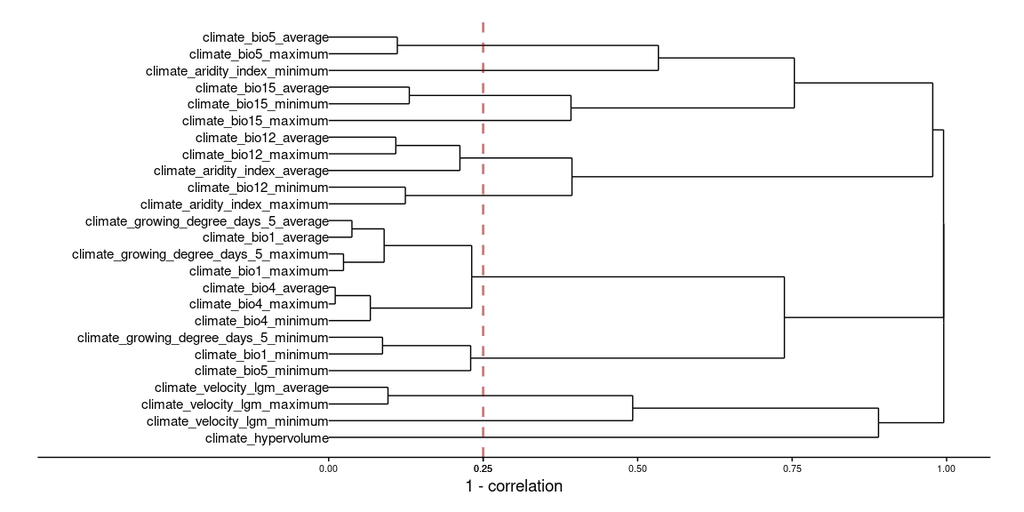

```r
p <- cor_dendrogram(training.df = ecoregions$data[, ecoregions$predictive.variables$climate])
```

There is a fair bit of climate variables correlated. To select a subgroup of uncorrelated variables I use the custom function `s_lower_vif()`, which iteratively removes variables using a variance inflation factor criteria while trying to keep the preference order defined by the user. In this case, aridity variables go first in the preference order, along with climate velocity, and the climate hypervolume.

```r
p <- s_lower_vif(
  training.df = ecoregions$data[, ecoregions$predictive.variables$climate],
  preference.order = c(
    "climate_aridity_index_average",
    "climate_aridity_index_maximum",
    "climate_hypervolume",
    "climate_velocity_lgm_average",
    "climate_velocity_lgm_maximum",
    "climate_bio1_average",
    "climate_bio12_average"
  )
)
```

```
Removed variables: climate_aridity_index_maximum, climate_velocity_lgm_maximum, climate_bio12_average, climate_bio4_average, climate_bio1_minimum, climate_bio1_maximum, climate_growing_degree_days_5_average, climate_bio5_average, climate_bio15_average, climate_growing_degree_days_5_maximum, climate_…
```

```r
p
```

```
$df
                       variable      vif
1         climate_bio15_maximum 2.188160
2  climate_velocity_lgm_average 2.151743
3  climate_velocity_lgm_minimum 1.950920
4         climate_bio15_minimum 1.757383
5 climate_aridity_index_average 1.407123
6           climate_hypervolume 1.217732
7          climate_bio1_average 1.136191

$vars
[1] "climate_aridity_index_average"
[2] "climate_hypervolume"
[3] "climate_velocity_lgm_average"
[4] "climate_bio1_average"
[5] "climate_bio15_minimum"
[6] "climate_bio15_maximum"
[7] "climate_velocity_lgm_minimum"

attr(,"class")
[1] "list"       "s_vif_auto"
```

```r
ecoregions$predictive.variables$climate <- p$vars
```

### landcover variables

Several of the landcover variables have modes centered in either 0 or 100, and have to be removed.

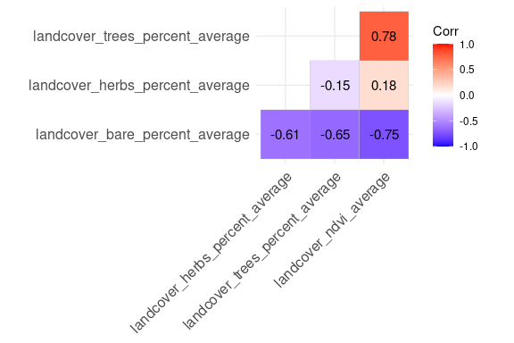

```r
ecoregions$predictive.variables$landcover <- c(
  "landcover_bare_percent_average",
  "landcover_herbs_percent_average",
  "landcover_trees_percent_average",
  "landcover_ndvi_average"
)

ggcorrplot(
  cor(ecoregions$data[, ecoregions$predictive.variables$landcover]),
  hc.order = TRUE,
  type = "lower",
   lab = TRUE
  )
```

None of the variables has enough correlation with the others to grant rejection.

### topography

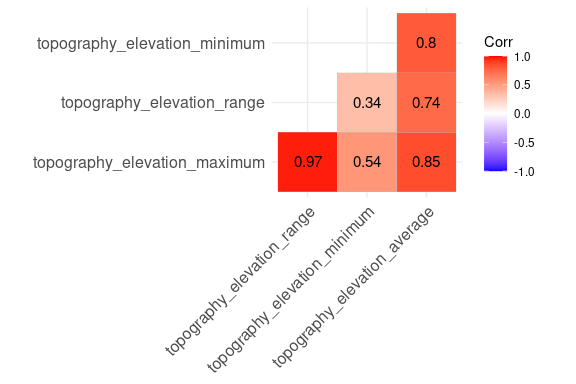

```r
ggcorrplot(
  cor(ecoregions$data[, ecoregions$predictive.variables$topography]),
  hc.order = TRUE,
  type = "lower",
   lab = TRUE
  )
```

Considering these correlations, I keep `topography_elevation_average` and `topography_elevation_range`.

```r
ecoregions$predictive.variables$topography <- c(
  "topography_elevation_average",
  "topography_elevation_range"
)
```

### fragmentation

There is a large number of fragmentation variables, and to speed-up variable selection here I use `s_lower_vif()` again, but without any particular order of preference.

```r
p <- s_lower_vif(
  training.df = ecoregions$data[, ecoregions$predictive.variables$fragmentation]
)
```

```
Removed variables: fragmentation_ca, fragmentation_area_mn, fragmentation_ai, fragmentation_contig_mn, fragmentation_clumpy, fragmentation_tca, fragmentation_cpland, fragmentation_lsi, fragmentation_nlsi, fragmentation_dcad, fragmentation_ndca, fragmentation_np, fragmentation_mesh, Done!
```

```r
p
```

```
$df
                variable      vif
1       fragmentation_pd 2.491499
2 fragmentation_shape_mn 2.330960
3       fragmentation_ed 2.198321
4  fragmentation_para_mn 1.900637
5 fragmentation_dcore_mn 1.605452
6 fragmentation_division 1.604087
7 fragmentation_cohesion 1.468440
8  fragmentation_core_mn 1.392991
9       fragmentation_te 1.209753

$vars
[1] "fragmentation_cohesion" "fragmentation_core_mn"
[3] "fragmentation_dcore_mn" "fragmentation_division"
[5] "fragmentation_ed"       "fragmentation_para_mn"
[7] "fragmentation_pd"       "fragmentation_shape_mn"
[9] "fragmentation_te"

attr(,"class")
[1] "list"       "s_vif_auto"
```

```r
ecoregions$predictive.variables$fragmentation <- p$vars
```

```r
#rebuilding the vector with all predictors
ecoregions$predictive.variables$all <- c(
  ecoregions$predictive.variables$bias,
  ecoregions$predictive.variables$neighbors,
  ecoregions$predictive.variables$human,
  ecoregions$predictive.variables$climate,
  ecoregions$predictive.variables$landcover,
  ecoregions$predictive.variables$topography,
  ecoregions$predictive.variables$fragmentation
)
```

### all

I apply again `s_lower_vif()` and set the variables I need for analyses downstream first in the argument `preference.order`.

```r
p <- s_lower_vif(
  training.df = ecoregions$data[, ecoregions$predictive.variables$all],
  preference.order = c(
    "bias_area_km2",
    "bias_species_per_record",
    "climate_aridity_index_average",
    "climate_hypervolume",
    "climate_velocity_lgm_average",
    "neighbors_count",
    "neighbors_percent_shared_edge",
    "human_population_density",
    "topography_elevation_average",
    "topography_elevation_range",
    "landcover_trees_percent_average",
    "landcover_herbs_percent_average",
    "fragmentation_cohesion",
    "fragmentation_division"
  )
)
```

```
Removed variables: topography_elevation_range, landcover_trees_percent_average, landcover_ndvi_average, climate_bio15_maximum, neighbors_average_aridity, climate_velocity_lgm_minimum, landcover_bare_percent_average, fragmentation_pd, fragmentation_te, Done!
```

```r
p
```

```
$df
                          variable      vif
1           fragmentation_shape_mn 2.391937
2          human_footprint_average 2.303287
3            fragmentation_para_mn 2.253669
4     topography_elevation_average 2.180733
5             climate_bio1_average 2.177479
6         human_population_density 2.172332
7                    bias_area_km2 2.089349
8            fragmentation_core_mn 1.864995
9    neighbors_percent_shared_edge 1.701230
10          fragmentation_dcore_mn 1.681159
11                human_population 1.649172
12                  neighbors_area 1.597782
13          fragmentation_division 1.595278
```

[output cut: 36 more lines]

Rebuilding the lists of variables in `ecoregions`.

```r
ecoregions$predictive.variables$bias <- p$vars[grepl("^bias", p$vars)]
ecoregions$predictive.variables$neighbors <- p$vars[grepl("^neighbors", p$vars)]
ecoregions$predictive.variables$human <- p$vars[grepl("^human", p$vars)]
ecoregions$predictive.variables$climate <- p$vars[grepl("^climate", p$vars)]
ecoregions$predictive.variables$landcover <- p$vars[grepl("^landcover", p$vars)]
ecoregions$predictive.variables$topography <- p$vars[grepl("^topography", p$vars)]
ecoregions$predictive.variables$fragmentation <- p$vars[grepl("^fragmentation", p$vars)]
ecoregions$predictive.variables$autocorrelation <- NA
ecoregions$predictive.variables$all <- p$vars

rm(p)
```

## ecoregions_pairs

### connection

Most of the connection variables are categorical, nothing to do here

### human

```r
cor(ecoregions_pairs$data[, ecoregions_pairs$predictive.variables$human])
```

```
                              diff_human_footprint_average
diff_human_footprint_average                     1.0000000
diff_human_population                           -0.3885477
diff_human_population_density                   -0.6427719
                              diff_human_population
diff_human_footprint_average             -0.3885477
diff_human_population                     1.0000000
diff_human_population_density             0.5061990
                              diff_human_population_density
diff_human_footprint_average                     -0.6427719
diff_human_population                             0.5061990
diff_human_population_density                     1.0000000
```

The human variables in `ecoregions_pairs` are not highly correlated, and all them are kept.

### climate

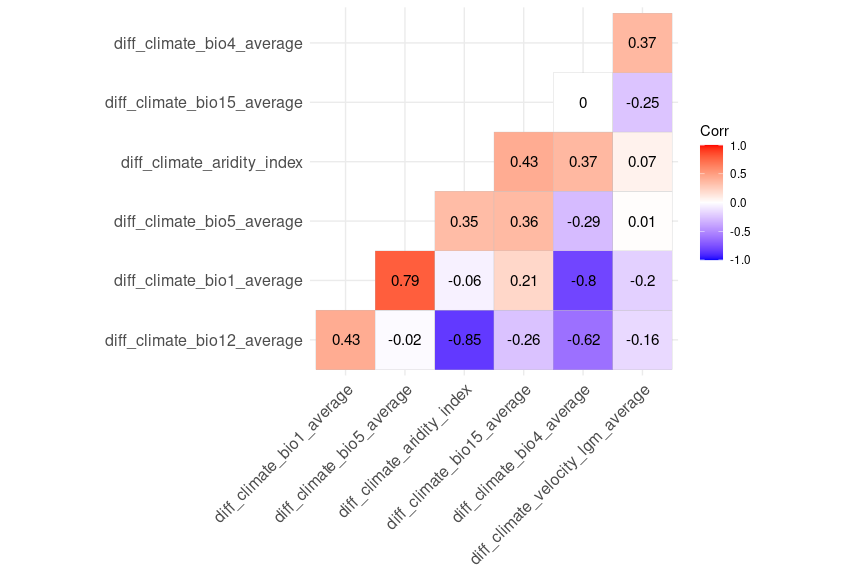

```r
ggcorrplot(
  cor(ecoregions_pairs$data[, ecoregions_pairs$predictive.variables$climate]),
  hc.order = TRUE,
  type = "lower",
   lab = TRUE
  )
```

To preserve `diff_climate_aridity_index` and `diff_climate_bio_1_average` I remove `diff_climate_bio12_average` and `diff_climate_bio4_average`.

```r
ecoregions_pairs$predictive.variables$climate <- ecoregions_pairs$predictive.variables$climate[
  !(ecoregions_pairs$predictive.variables$climate %in% c("diff_climate_bio12_average", "diff_climate_bio4_average"))]
```

### landcover

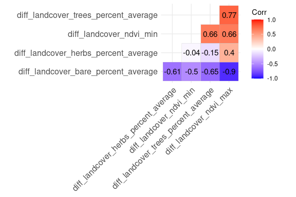

```r
ggcorrplot(
  cor(ecoregions_pairs$data[, ecoregions_pairs$predictive.variables$landcover]),
  hc.order = TRUE,
  type = "lower",
   lab = TRUE
  )
```

To give preference to the variables of the MODIS Vegetation Continuous Fields product I remove `diff_landcover_ndvi_max`.

```r
ecoregions_pairs$predictive.variables$landcover <- ecoregions_pairs$predictive.variables$landcover[
  !(ecoregions_pairs$predictive.variables$landcover %in% "diff_landcover_ndvi_max")]
```

### topography

There is only one topographic variable, nothing to do here.

### environmental overlap

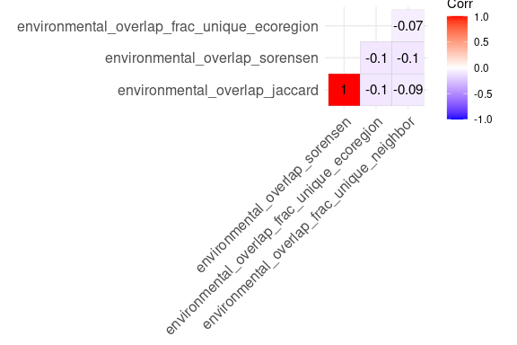

```r
ggcorrplot(
  cor(ecoregions_pairs$data[, ecoregions_pairs$predictive.variables$overlap]),
  hc.order = TRUE,
  type = "lower",
   lab = TRUE
  )
```

Since the Sorensen and Jaccard scores are linear combinations of each other, I keep Sorensen.

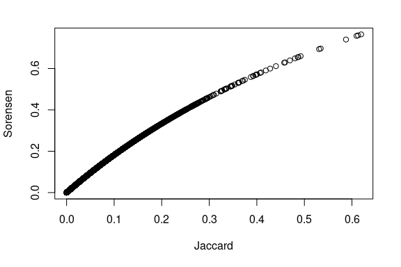

```r
plot(
  ecoregions_pairs$data$environmental_overlap_jaccard,
  ecoregions_pairs$data$environmental_overlap_sorensen,
  xlab = "Jaccard",
  ylab = "Sorensen"
  )
```

```r
ecoregions_pairs$predictive.variables$overlap <- "environmental_overlap_sorensen"
```

### all

```r
#rebuilding "all"
ecoregions_pairs$predictive.variables$all <- c(
  ecoregions_pairs$predictive.variables$connection,
  ecoregions_pairs$predictive.variables$human,
  ecoregions_pairs$predictive.variables$climate,
  ecoregions_pairs$predictive.variables$landcover,
  ecoregions_pairs$predictive.variables$topography,
  ecoregions_pairs$predictive.variables$overlap
)
```

```r
p <- s_lower_vif(
  training.df = ecoregions_pairs$data[, ecoregions_pairs$predictive.variables$all],
  preference.order = c(
    "connection_distance",
    "connection_shared_edge",
    "connection_area_diff",
    "environmental_overlap_sorensen",
    "diff_climate_aridity_index",
    "diff_human_population_density"
  )
)
```

```
Removed variables: diff_landcover_bare_percent_average, diff_climate_bio1_average, diff_landcover_ndvi_min, diff_landcover_trees_percent_average, diff_topography_elevation, Done!
```

```r
p
```

```
$df
                               variable      vif
1          diff_human_footprint_average 2.191806
2         diff_human_population_density 2.120782
3             diff_climate_bio5_average 1.711369
4            diff_climate_bio15_average 1.583279
5                 diff_human_population 1.564337
6            diff_climate_aridity_index 1.494644
7  diff_landcover_herbs_percent_average 1.392088
8              connection_latitude_diff 1.362109
9     diff_climate_velocity_lgm_average 1.360874
10                 connection_area_diff 1.272570
11            connection_longitude_diff 1.180142
12       environmental_overlap_sorensen 1.057087
13               connection_shared_edge 1.056744
```

[output cut: 20 more lines]

```r
#adding categorical variables back to p$vars
p$vars <- c(p$vars, c(
  "connection_same_biome",
  "connection_same_realm",
  "connection_same_continent",
  "connection_are_neighbors"
))
```

Rebuilding predictor groups

```r
ecoregions_pairs$predictive.variables$connection <- p$vars[grepl("^connection", p$vars)]
ecoregions_pairs$predictive.variables$human <- p$vars[grepl("^diff_human", p$vars)]
ecoregions_pairs$predictive.variables$climate <- p$vars[grepl("^diff_climate", p$vars)]
ecoregions_pairs$predictive.variables$landcover <-p$vars [grepl("^diff_landcover", p$vars)]
ecoregions_pairs$predictive.variables$topography <- NULL
ecoregions_pairs$predictive.variables$overlap <- p$vars[grepl("^environmental", p$vars)]
ecoregions_pairs$predictive.variables$all <- p$vars
```

# Betadiversity and distance matrices from ecoregions_pairs

From the dataset `ecoregions_pairs` several betadiversity and distance matrices can be extracted. Here I compute the matrices of the percentage of shared taxa and Sorensen’s Beta for species, genera, and families, and the matrix of geographic distances.

```r
#creating empty matrices
a.s <- a.g <- a.f <- bsor.s <- bsor.g <- bsor.f <- d <- matrix(
  data = NA,
  nrow = nrow(ecoregions$data),
  ncol = nrow(ecoregions$data),
  dimnames = list(
    rows = ecoregions$data$ecoregion_name,
    columns = ecoregions$data$ecoregion_name
  ))

#filling matrices with data from ecoregions_pairs
for(ecoregion.i in ecoregions$data$ecoregion_name){
  for(ecoregion.j in ecoregions$data$ecoregion_name){

    #getting indices
    i <- which(ecoregions$data$ecoregion_name == ecoregion.i)
    j <- which(ecoregions$data$ecoregion_name == ecoregion.j)

    #if same index
    if(i == j){

      #filling zero value
      a.s[i, j] <- a.g[i, j] <- a.f[i, j] <- bsor.s[i, j] <- bsor.g[i, j] <- bsor.f[i, j] <- d[i, j] <- d[j, i] <- 0

      #jumping to next iteration
      next

    } else {

      #index of the target row in ecoregions_pairs
      k <- which(ecoregions_pairs$data$ecoregion_name == ecoregion.i & ecoregions_pairs$data$neighbor_name == ecoregion.j)

      #filling matrix position
      a.s[i, j] <- a.s[j, i] <- 100 - ecoregions_pairs$data[k, "betadiversity_a_percent_species_vascular"]
      a.g[i, j] <- a.g[j, i] <- 100 - ecoregions_pairs$data[k, "betadiversity_a_percent_genera_vascular"]
      a.f[i, j] <- a.f[j, i] <- 100 - ecoregions_pairs$data[k, "betadiversity_a_percent_families_vascular"]
      bsor.s[i, j] <- bsor.s[j, i] <- ecoregions_pairs$data[k, "betadiversity_Bsor_species_vascular"]
      bsor.g[i, j] <- bsor.g[j, i] <- ecoregions_pairs$data[k, "betadiversity_Bsor_genera_vascular"]
      bsor.f[i, j] <- bsor.f[j, i] <- ecoregions_pairs$data[k, "betadiversity_Bsor_families_vascular"]
      d[i, j] <- d[j, i] <- ecoregions_pairs$data[k, "connection_distance"]

    }
  }
}

#saving results in ecoregions_pairs
ecoregions_pairs$distance_a_species_vascular <- a.s
ecoregions_pairs$distance_a_genera_vascular <- a.g
ecoregions_pairs$distance_a_families_vascular <- a.f
ecoregions_pairs$distance_bsor_species_vascular <- bsor.s
ecoregions_pairs$distance_bsor_genera_vascular <- bsor.g
ecoregions_pairs$distance_bsor_families_vascular <- bsor.f
ecoregions_pairs$distance <- d

rm(a.g, a.s, a.f, bsor.f, bsor.g, bsor.s, i, j, ecoregion.i, ecoregion.j, k)
```

```r
save(ecoregions, ecoregions_pairs, file = "ecoregions_plant_diversity_ready.RData")
```